# Problem

```python
import pandas as pd
import numpy as np
import matplotlib.pyplot as plt
%matplotlib inline
from matplotlib.pylab import rcParams
from pandas.plotting import scatter_matrix
import statsmodels.api as sm
from statsmodels import regression
import seaborn as sns
rcParams['figure.figsize']=10,8
from sklearn.preprocessing import StandardScaler
from sklearn.model_selection import train_test_split
from sklearn.feature_selection import RFE
from sklearn.linear_model import LinearRegression
from sklearn.metrics import mean_squared_error,mean_absolute_error
from sklearn.tree import DecisionTreeRegressor
from sklearn.model_selection import cross_val_score
from sklearn.ensemble import RandomForestRegressor
from sklearn.ensemble import GradientBoostingRegressor
from sklearn.svm import SVR
```

# Loading the data

```python
import pandas as pd
sf = pd.read_csv('House_prices_dataset.csv')
```

```python
sf.columns
```

```
Index(['address', 'info', 'z_address', 'bathrooms', 'bedrooms', 'finishedsqft',
       'lastsolddate', 'lastsoldprice', 'latitude', 'longitude',
       'neighborhood', 'totalrooms', 'usecode', 'yearbuilt', 'zestimate',
       'zindexvalue', 'zipcode', 'zpid'],
      dtype='object')
```

```python
sf.head()
```

|  | address | info | z_address | bathrooms | bedrooms | finishedsqft | lastsolddate | lastsoldprice | latitude | longitude | neighborhood | totalrooms | usecode | yearbuilt | zestimate | zindexvalue | zipcode | zpid |
| --- | --- | --- | --- | --- | --- | --- | --- | --- | --- | --- | --- | --- | --- | --- | --- | --- | --- | --- |
| 0 | Address: 1160 Mission Street #2007 | San FranciscoSales price: 1300000Sales date: ... | 1160 Mission St UNIT 2007 | 2 | 2 | 1043 | 02/17/2016 | 1300000 | 37.778705 | -122.412635 | South of Market | 4 | Condominium | 2007 | 1167508 | 975,700 | 94103 | 83152781 |
| 1 | Address: 260 King Street #475 | San FranciscoSales price: 750000Sales date: 0... | 260 King St UNIT 475 | 1 | 1 | 903 | 02/17/2016 | 750000 | 37.777641 | -122.393417 | South of Market | 2 | Condominium | 2004 | 823719 | 975,700 | 94107 | 69819817 |
| 2 | Address: 560 Missouri Street #B | San FranciscoSales price: 1495000Sales date: ... | 560 Missouri St # B | 4 | 3 | 1425 | 02/17/2016 | 1495000 | 37.759198 | -122.396516 | Potrero Hill | 7 | Condominium | 2003 | 1708594 | 1,277,600 | 94107 | 64972847 |
| 3 | Address: 350 Missouri Street | San FranciscoSales price: 2700000Sales date: ... | 350 Missouri St | 3 | 3 | 2231 | 02/17/2016 | 2700000 | 37.761886 | -122.396769 | Potrero Hill | 6 | SingleFamily | 1927 | 2411236 | 1,277,600 | 94107 | 15149489 |
| 4 | Address: 3658 Folsom Street | San FranciscoSales price: 1530000Sales date: ... | 3658 Folsom St | 3 | 3 | 1300 | 02/17/2016 | 1530000 | 37.740795 | -122.413453 | Bernal Heights | 6 | SingleFamily | 1900 | 1918539 | 1,248,000 | 94110 | 15161978 |

```python
sf.tail()
```

|  | address | info | z_address | bathrooms | bedrooms | finishedsqft | lastsolddate | lastsoldprice | latitude | longitude | neighborhood | totalrooms | usecode | yearbuilt | zestimate | zindexvalue | zipcode | zpid |
| --- | --- | --- | --- | --- | --- | --- | --- | --- | --- | --- | --- | --- | --- | --- | --- | --- | --- | --- |
| 11325 | Address: 149 Laidley Street | San FranciscoSales price: 1950000Sales date: ... | 149 Laidley St | 2 | 3 | 2100 | 02/03/2016 | 1950000 | 37.739623 | -122.428899 | Glen Park | 5 | SingleFamily | 1900 | 1895813 | 1,628,900 | 94131 | 15184023 |
| 11326 | Address: 737 Tehama Street #1 | San FranciscoSales price: 1030000Sales date: ... | 737 Tehama St # 1 | 2 | 2 | 977 | 02/02/2016 | 1030000 | 37.775184 | -122.411567 | South of Market | 4 | MultiFamily2To4 | 2006 | 999443 | 957,300 | 94103 | 79845585 |
| 11327 | Address: 319 De Long Street | San FranciscoSales price: 565000Sales date: 0... | 319 De Long St | 1 | 2 | 875 | 02/02/2016 | 565000 | 37.709411 | -122.465031 | Outer Mission | 3 | SingleFamily | 1950 | 639167 | 804,400 | 94112 | 15196286 |
| 11328 | Address: 1655 48th Avenue | San FranciscoSales price: 762000Sales date: 0... | 1655 48th Ave | 1 | 2 | 697 | 02/02/2016 | 762000 | 37.755586 | -122.508063 | Outer Sunset | 3 | SingleFamily | 1904 | 703197 | 1,030,300 | 94122 | 15108054 |
| 11329 | Address: 4219 Folsom Street | San FranciscoSales price: 950000Sales date: 0... | 4219 Folsom St | 2 | 3 | 1539 | 02/01/2016 | 950000 | 37.734334 | -122.413534 | Bernal Heights | 5 | SingleFamily | 1976 | 962071 | 1,214,400 | 94110 | 15164756 |

```python
sf.info()
```

```
<class 'pandas.core.frame.DataFrame'>
RangeIndex: 11330 entries, 0 to 11329
Data columns (total 18 columns):
 #   Column         Non-Null Count  Dtype
---  ------         --------------  -----
 0   address        11330 non-null  object
 1   info           11330 non-null  object
 2   z_address      11330 non-null  object
 3   bathrooms      11330 non-null  int64
 4   bedrooms       11330 non-null  int64
 5   finishedsqft   11330 non-null  int64
 6   lastsolddate   11330 non-null  object
 7   lastsoldprice  11330 non-null  int64
 8   latitude       11330 non-null  float64
 9   longitude      11330 non-null  float64
 10  neighborhood   11330 non-null  object
 11  totalrooms     11330 non-null  int64
 12  usecode        11330 non-null  object
 13  yearbuilt      11330 non-null  int64
 14  zestimate      11330 non-null  int64
 15  zindexvalue    11330 non-null  object
 16  zipcode        11330 non-null  int64
 17  zpid           11330 non-null  int64
dtypes: float64(2), int64(9), object(7)
memory usage: 1.6+ MB
```

```python
sf.shape
```

```
(11330, 18)
```

# Basic statistics

```python
sf.describe().T
```

|  | count | mean | std | min | 25% | 50% | 75% | max |
| --- | --- | --- | --- | --- | --- | --- | --- | --- |
| bathrooms | 11330.0 | 1.913327e+00 | 1.015151e+00 | 0.000000e+00 | 1.000000e+00 | 2.000000e+00 | 2.000000e+00 | 1.400000e+01 |
| bedrooms | 11330.0 | 2.614475e+00 | 1.299457e+00 | 0.000000e+00 | 2.000000e+00 | 2.000000e+00 | 3.000000e+00 | 2.000000e+01 |
| finishedsqft | 11330.0 | 1.585421e+03 | 9.219782e+02 | 1.000000e+00 | 1.019000e+03 | 1.362000e+03 | 1.876000e+03 | 2.727500e+04 |
| lastsoldprice | 11330.0 | 1.263928e+06 | 1.042079e+06 | 5.350000e+02 | 7.292500e+05 | 9.900000e+05 | 1.450000e+06 | 2.388900e+07 |
| latitude | 11330.0 | 3.775971e+01 | 2.557802e-02 | 3.770817e+01 | 3.773929e+01 | 3.776051e+01 | 3.778139e+01 | 3.780608e+01 |
| longitude | 11330.0 | -1.224365e+02 | 3.074340e-02 | -1.225107e+02 | -1.224552e+02 | -1.224325e+02 | -1.224134e+02 | -1.223812e+02 |
| totalrooms | 11330.0 | 4.527802e+00 | 2.142380e+00 | 0.000000e+00 | 3.000000e+00 | 4.000000e+00 | 5.000000e+00 | 2.500000e+01 |
| yearbuilt | 11330.0 | 1.948498e+03 | 3.791120e+01 | 1.860000e+03 | 1.916000e+03 | 1.940000e+03 | 1.986000e+03 | 2.016000e+03 |
| zestimate | 11330.0 | 1.565695e+06 | 1.229417e+06 | 4.323850e+05 | 9.052375e+05 | 1.230758e+06 | 1.731170e+06 | 1.553325e+07 |
| zipcode | 11330.0 | 9.411691e+04 | 9.400877e+00 | 9.410200e+04 | 9.411000e+04 | 9.411500e+04 | 9.412300e+04 | 9.415800e+04 |
| zpid | 11330.0 | 3.689973e+07 | 7.800741e+07 | 1.506329e+07 | 1.510847e+07 | 1.515697e+07 | 5.970040e+07 | 2.146999e+09 |

The count, mean, min and max rows are self-explanatory. The std shows the standard deviation, and the 25%, 50% and 75% rows show the corresponding percentiles.

# Data Cleaning

There are several features that we do not need, such as “info”, “z_address”, “zipcode”(We have “neighborhood” as a location variable), “zipid” and “zestimate”(This is the price estimated by Zillow, we don’t want our model to be affected by this), so, we will drop them.

```python
sf.drop(["info"], axis=1, inplace=True)
sf.drop(["z_address"], axis=1, inplace=True)
sf.drop(["zipcode"], axis=1, inplace=True)
sf.drop(["zpid"], axis=1, inplace=True)
sf.drop(["zestimate"], axis=1, inplace=True)
sf.head()
```

|  | address | bathrooms | bedrooms | finishedsqft | lastsolddate | lastsoldprice | latitude | longitude | neighborhood | totalrooms | usecode | yearbuilt | zindexvalue |
| --- | --- | --- | --- | --- | --- | --- | --- | --- | --- | --- | --- | --- | --- |
| 0 | Address: 1160 Mission Street #2007 | 2 | 2 | 1043 | 02/17/2016 | 1300000 | 37.778705 | -122.412635 | South of Market | 4 | Condominium | 2007 | 975,700 |
| 1 | Address: 260 King Street #475 | 1 | 1 | 903 | 02/17/2016 | 750000 | 37.777641 | -122.393417 | South of Market | 2 | Condominium | 2004 | 975,700 |
| 2 | Address: 560 Missouri Street #B | 4 | 3 | 1425 | 02/17/2016 | 1495000 | 37.759198 | -122.396516 | Potrero Hill | 7 | Condominium | 2003 | 1,277,600 |
| 3 | Address: 350 Missouri Street | 3 | 3 | 2231 | 02/17/2016 | 2700000 | 37.761886 | -122.396769 | Potrero Hill | 6 | SingleFamily | 1927 | 1,277,600 |
| 4 | Address: 3658 Folsom Street | 3 | 3 | 1300 | 02/17/2016 | 1530000 | 37.740795 | -122.413453 | Bernal Heights | 6 | SingleFamily | 1900 | 1,248,000 |

```python
sf.info()
```

```
<class 'pandas.core.frame.DataFrame'>
RangeIndex: 11330 entries, 0 to 11329
Data columns (total 13 columns):
 #   Column         Non-Null Count  Dtype
---  ------         --------------  -----
 0   address        11330 non-null  object
 1   bathrooms      11330 non-null  int64
 2   bedrooms       11330 non-null  int64
 3   finishedsqft   11330 non-null  int64
 4   lastsolddate   11330 non-null  object
 5   lastsoldprice  11330 non-null  int64
 6   latitude       11330 non-null  float64
 7   longitude      11330 non-null  float64
 8   neighborhood   11330 non-null  object
 9   totalrooms     11330 non-null  int64
 10  usecode        11330 non-null  object
 11  yearbuilt      11330 non-null  int64
 12  zindexvalue    11330 non-null  object
dtypes: float64(2), int64(6), object(5)
memory usage: 1.1+ MB
```

```python
print(sf.address.unique())
```

```
['Address: 1160 Mission Street #2007' 'Address: 260 King Street #475'
 'Address: 560 Missouri Street #B' ... 'Address: 415 Victoria Street'
 'Address: 527 Woolsey Street' 'Address: 1 Crescent Way #1103']
```

```python
sf.bathrooms.unique()
```

```
array([ 2,  1,  4,  3,  5,  7,  6, 14,  8,  0, 12,  9, 13], dtype=int64)
```

```python
sf.bedrooms.unique()
```

```
array([ 2,  1,  3,  4,  5,  0,  7,  8,  6,  9, 12, 10, 16, 11, 20, 14, 13],
      dtype=int64)
```

```python
sf.finishedsqft.unique()
```

```
array([1043,  903, 1425, ..., 1157, 2278, 3046], dtype=int64)
```

```python
sf.lastsolddate.unique()
```

```
array(['02/17/2016', '08/12/2015', '02/16/2016', '02/12/2016',
       '02/11/2016', '02/10/2016', '02/09/2016', '02/08/2016',
       '02/05/2016', '02/04/2016', '06/11/2015', '02/03/2016',
       '02/02/2016', '02/01/2016', '01/29/2016', '01/28/2016',
       '01/27/2016', '03/24/2015', '01/26/2016', '01/25/2016',
       '01/22/2016', '01/21/2016', '01/20/2016', '01/19/2016',
       '01/15/2016', '01/14/2016', '01/13/2016', '01/12/2016',
       '01/11/2016', '01/08/2016', '01/07/2016', '01/06/2016',
       '11/25/2009', '01/05/2016', '01/04/2016', '12/31/2015',
       '12/30/2015', '01/03/2016', '12/29/2015', '12/28/2015',
       '12/24/2015', '12/23/2015', '12/22/2015', '12/21/2015',
       '12/18/2015', '12/17/2015', '07/16/2014', '12/20/2015',
       '12/16/2015', '12/15/2015', '12/17/2014', '12/14/2015',
       '12/11/2015', '12/10/2015', '12/09/2015', '12/08/2015',
       '12/07/2015', '12/04/2015', '12/03/2015', '12/02/2015',
       '12/01/2015', '11/30/2015', '11/25/2015', '11/24/2015',
       '11/23/2015', '11/20/2015', '11/19/2015', '11/18/2015',
       '11/17/2015', '01/03/2013', '11/16/2015', '11/13/2015',
       '02/28/2014', '11/12/2015', '03/13/2015', '11/10/2015',
       '11/09/2015', '11/06/2015', '11/05/2015', '11/04/2015',
       '11/03/2015', '11/02/2015', '10/30/2015', '10/31/2015',
       '10/29/2015', '10/28/2015', '10/27/2015', '11/21/2013',
       '10/26/2015', '10/23/2015', '10/22/2015', '10/21/2015',
       '10/20/2015', '10/19/2015', '10/16/2015', '10/15/2015',
       '10/14/2015', '10/13/2015', '10/09/2015', '10/08/2015',
       '10/07/2015', '10/06/2015', '10/05/2015', '10/02/2015',
       '10/01/2015', '09/30/2015', '09/06/2007', '09/29/2015',
       '09/28/2015', '09/25/2015', '09/24/2015', '09/27/2015',
       '09/23/2015', '10/25/2013', '09/22/2015', '09/21/2015',
       '09/18/2015', '09/16/2015', '09/15/2015', '09/14/2015',
       '09/11/2015', '09/10/2015', '09/09/2015', '09/08/2015',
       '09/04/2015', '09/03/2015', '09/02/2015', '09/01/2015',
       '08/31/2015', '08/28/2015', '08/27/2015', '08/26/2015',
       '08/24/2015', '08/14/2015', '08/13/2015', '08/11/2015',
       '08/10/2015', '08/07/2015', '08/06/2015', '08/05/2015',
       '08/04/2015', '08/03/2015', '07/31/2015', '07/30/2015',
       '07/29/2015', '07/28/2015', '08/01/2015', '07/27/2015',
       '07/24/2015', '07/23/2015', '07/22/2015', '07/21/2015',
       '07/20/2015', '07/17/2015', '07/16/2015', '07/15/2015',
       '07/14/2015', '07/13/2015', '07/10/2015', '07/09/2015',
```

[output cut: 184 more lines]

```
       '09/07/2012', '02/14/2002', '05/23/2013', '09/05/2012',
       '09/04/2012', '08/31/2012', '06/24/2013', '08/30/2012',
       '01/30/1997', '08/29/2012', '08/28/2012', '08/27/2012',
       '08/24/2012', '03/16/2016', '08/23/2012', '08/22/2012',
       '08/21/2012', '08/20/2012', '10/02/1996', '08/17/2012',
       '08/16/2012', '08/15/2012', '08/14/2012', '08/13/2012',
       '08/01/2008', '08/10/2012', '08/09/2012', '08/08/2012',
       '08/07/2012', '04/16/2012', '02/08/2013', '08/06/2012',
       '08/03/2012', '12/22/2009', '08/02/2012', '01/18/2012',
       '07/31/2012', '08/01/2012', '07/21/2006', '07/07/2005',
       '07/30/2012', '10/20/2011', '10/19/2011', '10/18/2011',
       '10/17/2011', '12/21/2011', '10/14/2011', '10/13/2011',
       '10/12/2011', '12/01/2011', '10/11/2011', '10/07/2011',
       '03/23/2012', '03/16/2007', '05/15/1997', '02/28/2016',
       '02/25/2016', '02/18/2016'], dtype=object)
```

```python
sf.lastsolddate.min(), sf.lastsolddate.max()
```

```
('01/02/2013', '12/31/2015')
```

```python
sf.lastsoldprice.unique()
```

```
array([1300000,  750000, 1495000, ..., 1290500, 1069000,  834000],
      dtype=int64)
```

```python
sf.latitude.unique()
```

```
array([37.778705, 37.777641, 37.759198, ..., 37.755472, 37.718224,
       37.723853])
```

```python
sf.longitude.unique()
```

```
array([-122.412635, -122.393417, -122.396516, ..., -122.467116,
       -122.465576, -122.407012])
```

```python
sf.neighborhood.unique()
```

```
array(['South of Market', 'Potrero Hill', 'Bernal Heights',
       'Crocker Amazon', 'Oceanview', 'Mission Terrace', 'Noe Valley',
       'Hayes Valley', 'Portola',
       'Eureka Valley - Dolores Heights - Castro', 'Lake', 'Inner Sunset',
       'Sunnyside', 'Van Ness - Civic Center', 'Mission', 'Nob Hill',
       'Lower Pacific Heights', 'Central Richmond', 'Outer Sunset',
       'Bayview', 'Westwood Highlands', 'Forest Hill Extension',
       'Lakeshore', 'Corona Heights', 'Central Sunset', 'Pacific Heights',
       'West Portal', 'Lone Mountain', 'North Panhandle',
       'Diamond Heights', 'Downtown', 'Western Addition',
       'Presidio Heights', 'Midtown Terrace', 'Parnassus - Ashbury',
       'Silver Terrace', 'South Beach', 'Glen Park', 'Outer Mission',
       'Yerba Buena', 'Outer Parkside', 'Ingleside Heights',
       'Outer Richmond', 'Telegraph Hill', 'Visitacion Valley',
       'Buena Vista Park', 'Cow Hollow', 'Excelsior',
       'Mount Davidson Manor', 'Twin Peaks', 'Haight-Ashbury',
       'St. Francis Wood', 'Ingleside', 'Marina', 'Merced Heights',
       'Russian Hill', 'Golden Gate Heights', 'Sea Cliff',
       'Central Waterfront - Dogpatch', 'Westwood Park', 'Parkside',
       'Inner Richmond', 'Miraloma Park', 'Little Hollywood',
       'Ingleside Terrace', 'North Beach', 'Forest Hill',
       'Inner Parkside', 'Lakeside', 'Daly City', 'North Waterfront'],
      dtype=object)
```

```python
sf.totalrooms.unique()
```

```
array([ 4,  2,  7,  6,  3,  5, 10,  1,  8, 12, 11,  9, 16, 14, 15, 21, 13,
        0, 23, 17, 18, 24, 20, 25], dtype=int64)
```

```python
sf.usecode.unique()
```

```
array(['Condominium', 'SingleFamily', 'MultiFamily2To4', 'Miscellaneous',
       'Duplex', 'Townhouse', 'Mobile', 'Apartment', 'Cooperative',
       'MultiFamily5Plus'], dtype=object)
```

```python
sf.yearbuilt.unique()
```

```
array([2007, 2004, 2003, 1927, 1900, 1924, 1939, 1912, 1890, 1953, 2008,
       1981, 1926, 1966, 1906, 2002, 2009, 1902, 2005, 1914, 1922, 1905,
       1931, 1940, 1937, 1950, 1936, 1943, 1904, 1911, 1932, 1982, 1925,
       1996, 2001, 1980, 1963, 2000, 1910, 1955, 1929, 1921, 1913, 1964,
       1949, 1908, 1941, 1918, 2006, 1976, 1997, 1885, 1962, 1999, 1916,
       1968, 1987, 1974, 1947, 1870, 2012, 1938, 1942, 1961, 1985, 1907,
       1989, 1928, 1984, 1923, 1944, 1970, 1930, 1879, 1977, 1995, 1978,
       1954, 1951, 1957, 1972, 1998, 1917, 1935, 1919, 1992, 1915, 1991,
       1965, 1946, 2013, 1986, 1920, 1979, 1958, 1994, 2014, 1960, 1945,
       1934, 2015, 1973, 1948, 1983, 1975, 1993, 2010, 1952, 1959, 1933,
       1990, 1988, 1909, 1872, 1956, 1967, 1969, 1901, 1876, 1903, 1878,
       1884, 1898, 1888, 1877, 1875, 1897, 1971, 1895, 1880, 1896, 2011,
       1891, 1894, 1886, 1893, 1892, 1899, 1889, 1882, 1866, 1883, 1887,
       1871, 1860, 2016, 1863], dtype=int64)
```

```python
sf.zindexvalue.unique()
```

```
array(['975,700', '1,277,600', '1,248,000', '823,000', '762,700',
       '992,600', '1,782,000', '1,224,800', '888,400', '1,744,100',
       '2,244,500', '1,357,900', '1,038,200', '855,500', '1,185,400',
       '1,459,200', '1,178,700', '1,485,300', '1,031,800', '731,900',
       '1,424,100', '1,669,300', '1,264,800', '1,475,100', '1,125,700',
       '1,910,700', '1,565,000', '1,447,700', '1,231,800', '1,098,500',
       '807,800', '983,400', '5,333,500', '1,117,200', '2,151,400',
       '736,700', '1,286,900', '1,660,200', '814,200', '1,006,900',
       '981,900', '710,500', '1,214,000', '1,238,700', '707,100',
       '1,500,900', '2,151,200', '767,600', '1,378,600', '1,180,100',
       '1,369,500', '3,056,100', '2,186,800', '874,200', '1,630,000',
       '1,476,600', '4,464,800', '1,129,000', '1,215,700', '1,112,900',
       '1,685,300', '1,250,700', '757,700', '1,624,900', '1,235,600',
       '1,975,100', '1,318,200', '1,390,900', '1,884,400', '1,214,400',
       '2,111,800', '1,111,300', '2,134,300', '719,000', '1,030,800',
       '1,628,900', '1,751,900', '1,218,900', '1,269,100', '1,679,000',
       '688,100', '1,608,800', '957,300', '1,167,700', '986,000',
       '982,900', '5,244,900', '1,070,100', '891,600', '1,440,700',
       '1,449,300', '883,100', '1,264,000', '1,094,000', '1,202,900',
       '1,337,700', '1,480,400', '1,187,700', '1,030,300', '1,215,500',
       '749,400', '752,700', '757,400', '817,600', '1,159,200',
       '1,419,600', '1,348,400', '690,400', '993,200', '3,009,100',
       '839,200', '2,157,700', '799,700', '1,926,800', '1,621,200',
       '1,551,600', '1,124,600', '971,300', '1,227,600', '1,146,900',
       '2,202,400', '1,718,500', '1,304,500', '795,400', '804,400',
       '1,191,600', '1,211,900', '1,393,200', '1,370,500', '720,300',
       '1,237,900', '1,108,400', '4,400,200', '1,449,000', '1,470,700',
       '1,657,500', '1,388,300', '750,300', '914,900'], dtype=object)
```

The data type of “zindexvalue” should be numeric, so let’s change that.

```python
sf['zindexvalue'] = sf['zindexvalue'].str.replace(',', '')
sf['zindexvalue'] = pd.to_numeric(sf['zindexvalue'], errors='coerce')
sf.zindexvalue.unique()
```

```
array([ 975700, 1277600, 1248000,  823000,  762700,  992600, 1782000,
       1224800,  888400, 1744100, 2244500, 1357900, 1038200,  855500,
       1185400, 1459200, 1178700, 1485300, 1031800,  731900, 1424100,
       1669300, 1264800, 1475100, 1125700, 1910700, 1565000, 1447700,
       1231800, 1098500,  807800,  983400, 5333500, 1117200, 2151400,
        736700, 1286900, 1660200,  814200, 1006900,  981900,  710500,
       1214000, 1238700,  707100, 1500900, 2151200,  767600, 1378600,
       1180100, 1369500, 3056100, 2186800,  874200, 1630000, 1476600,
       4464800, 1129000, 1215700, 1112900, 1685300, 1250700,  757700,
       1624900, 1235600, 1975100, 1318200, 1390900, 1884400, 1214400,
       2111800, 1111300, 2134300,  719000, 1030800, 1628900, 1751900,
       1218900, 1269100, 1679000,  688100, 1608800,  957300, 1167700,
        986000,  982900, 5244900, 1070100,  891600, 1440700, 1449300,
        883100, 1264000, 1094000, 1202900, 1337700, 1480400, 1187700,
       1030300, 1215500,  749400,  752700,  757400,  817600, 1159200,
       1419600, 1348400,  690400,  993200, 3009100,  839200, 2157700,
        799700, 1926800, 1621200, 1551600, 1124600,  971300, 1227600,
       1146900, 2202400, 1718500, 1304500,  795400,  804400, 1191600,
       1211900, 1393200, 1370500,  720300, 1237900, 1108400, 4400200,
       1449000, 1470700, 1657500, 1388300,  750300,  914900], dtype=int64)
```

# Exploratory data analysis

To get a feel for the type of data we are dealing with, we plot a histogram for each numeric variable.

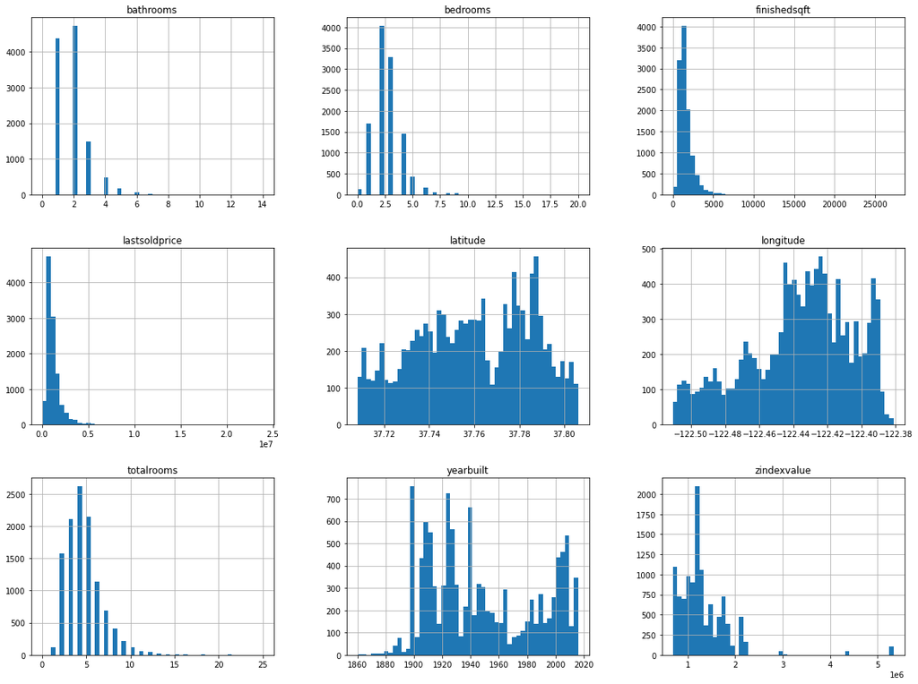

```python
%matplotlib inline
import matplotlib.pyplot as plt
sf.hist(bins=50, figsize=(20,15))
plt.savefig("attribute_histogram_plots")
plt.show()
```

Let’s create a scatter plot with latitude and longitude to visualize the data:

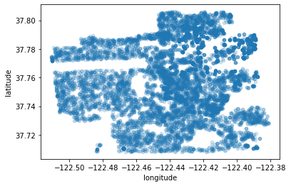

```python
sf.plot(kind="scatter", x="longitude", y="latitude", alpha=0.2)
plt.savefig('map1.png')
```

Now let’s color code from the most expensive to the least expensive areas:

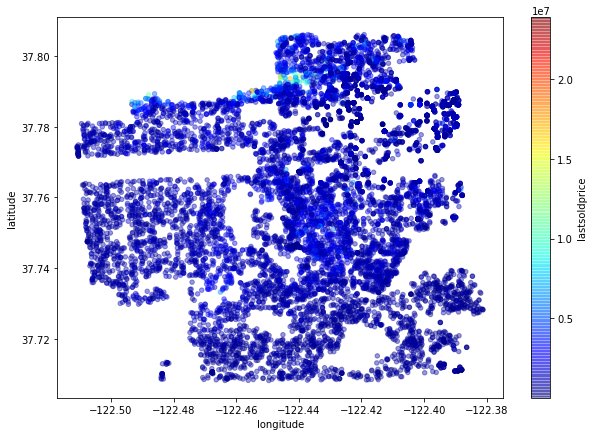

```python
sf.plot(kind="scatter", x="longitude", y="latitude", alpha=0.4, figsize=(10,7),
    c="lastsoldprice", cmap=plt.get_cmap("jet"), colorbar=True,
    sharex=False)
plt.savefig('map2.png')
```

This image tells us that the most expensive houses sold were in the north area.

The variable we are going to predict is the “last sold price”. So let’s look at how much each independent variable correlates with this dependent variable.

```python
corr_matrix = sf.corr()
corr_matrix["lastsoldprice"].sort_values(ascending=False)
```

```
lastsoldprice    1.000000
finishedsqft     0.647208
bathrooms        0.508307
totalrooms       0.480734
zindexvalue      0.460429
bedrooms         0.395478
latitude         0.283107
longitude       -0.052595
yearbuilt       -0.189055
Name: lastsoldprice, dtype: float64
```

The last sold price tends to go up when the finished sqft and number of bathrooms go up. You can see a small negative correlation between the year built and the last sold price. Finally, coefficients close to zero mean that there is no linear correlation.

We are now going to visualize the correlation between variables by using Pandas’ scatter_matrix function. We will just focus on a few promising variables, that seem the most correlated with the last sold price.

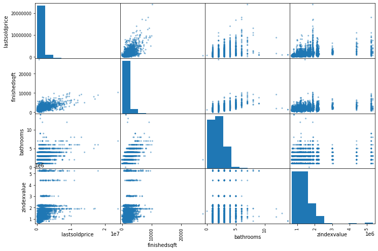

```python
attributes = ["lastsoldprice", "finishedsqft", "bathrooms", "zindexvalue"]
scatter_matrix(sf[attributes], figsize=(12, 8))
plt.savefig('matrix.png')
```

The most promising variable for predicting the last sold price is the finished sqft, so let’s zoom in on their correlation scatter plot.

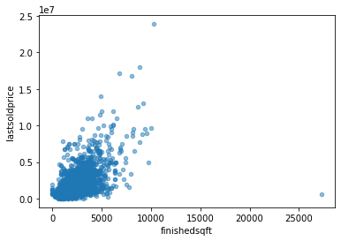

```python
sf.plot(kind="scatter", x="finishedsqft", y="lastsoldprice", alpha=0.5)
plt.savefig('scatter.png')
```

# Feature Engineering

There are 71 neighborhoods in the data, and we are going to group them.

```python
len(sf['neighborhood'].value_counts())
```

```
71
```

Because each house has different square footage and each neighborhood has different home prices, what we really need is the price per sqft. So, we add a new variable “price_per_sqft”.

```python
sf['price_per_sqft'] = sf['lastsoldprice']/sf['finishedsqft']
```

The following steps cluster the neighborhood into three groups: 1. low price; 2. high price low frequency; 3. high price high frequency.

```python
freq = sf.groupby('neighborhood').count()['address']
#mean_price: average price per sqft
mean = sf.groupby('neighborhood').mean()['price_per_sqft']
cluster = pd.concat([freq, mean], axis=1)
cluster['neighborhood'] = cluster.index
```

```python
cluster.columns = ['freq', 'price_per_sqft','neighborhood']
```

```python
cluster.describe()
```

|  | freq | price_per_sqft |
| --- | --- | --- |
| count | 71.000000 | 71.000000 |
| mean | 159.577465 | 1664.908308 |
| std | 126.572696 | 3619.277749 |
| min | 3.000000 | 374.201197 |
| 25% | 67.500000 | 613.337664 |
| 50% | 123.000000 | 756.246284 |
| 75% | 210.500000 | 985.156646 |
| max | 540.000000 | 26914.471572 |

These are the low price neighborhoods:

```python
cluster1 = cluster[cluster.price_per_sqft < 756]
cluster1.index
```

```
Index(['Bayview', 'Central Richmond', 'Central Sunset', 'Crocker Amazon',
       'Daly City', 'Diamond Heights', 'Excelsior', 'Forest Hill',
       'Forest Hill Extension', 'Golden Gate Heights', 'Ingleside',
       'Ingleside Heights', 'Ingleside Terrace', 'Inner Parkside',
       'Inner Richmond', 'Inner Sunset', 'Lakeshore', 'Little Hollywood',
       'Merced Heights', 'Mission Terrace', 'Mount Davidson Manor',
       'Oceanview', 'Outer Mission', 'Outer Parkside', 'Outer Richmond',
       'Outer Sunset', 'Parkside', 'Portola', 'Silver Terrace', 'Sunnyside',
       'Visitacion Valley', 'West Portal', 'Western Addition',
       'Westwood Highlands', 'Westwood Park'],
      dtype='object', name='neighborhood')
```

These are the high price and low frequency neighborhoods:

```python
cluster_temp = cluster[cluster.price_per_sqft >= 756]
cluster2 = cluster_temp[cluster_temp.freq <123]
cluster2.index
```

```
Index(['Buena Vista Park', 'Central Waterfront - Dogpatch', 'Corona Heights',
       'Haight-Ashbury', 'Lakeside', 'Lone Mountain', 'Midtown Terrace',
       'North Beach', 'North Waterfront', 'Parnassus - Ashbury',
       'Presidio Heights', 'Sea Cliff', 'St. Francis Wood', 'Telegraph Hill',
       'Twin Peaks'],
      dtype='object', name='neighborhood')
```

These are the high price and high frequency neighborhoods:

```python
cluster3 = cluster_temp[cluster_temp.freq >=123]
cluster3.index
```

```
Index(['Bernal Heights', 'Cow Hollow', 'Downtown',
       'Eureka Valley - Dolores Heights - Castro', 'Glen Park', 'Hayes Valley',
       'Lake', 'Lower Pacific Heights', 'Marina', 'Miraloma Park', 'Mission',
       'Nob Hill', 'Noe Valley', 'North Panhandle', 'Pacific Heights',
       'Potrero Hill', 'Russian Hill', 'South Beach', 'South of Market',
       'Van Ness - Civic Center', 'Yerba Buena'],
      dtype='object', name='neighborhood')
```

Add neighborhoodg column based on the clusters

```python
def get_group(x):
    if x in cluster1.index:
        return 'neighborhood_low_price'
    elif x in cluster2.index:
        return 'neighborhood_high_price_low_freq'
    else:
        return 'neighborhood_high_price_high_freq'
sf['neighborhoodg'] = sf.neighborhood.apply(get_group)
```

```python
sf.info()
```

```
<class 'pandas.core.frame.DataFrame'>
RangeIndex: 11330 entries, 0 to 11329
Data columns (total 15 columns):
 #   Column          Non-Null Count  Dtype
---  ------          --------------  -----
 0   address         11330 non-null  object
 1   bathrooms       11330 non-null  int64
 2   bedrooms        11330 non-null  int64
 3   finishedsqft    11330 non-null  int64
 4   lastsolddate    11330 non-null  object
 5   lastsoldprice   11330 non-null  int64
 6   latitude        11330 non-null  float64
 7   longitude       11330 non-null  float64
 8   neighborhood    11330 non-null  object
 9   totalrooms      11330 non-null  int64
 10  usecode         11330 non-null  object
 11  yearbuilt       11330 non-null  int64
 12  zindexvalue     11330 non-null  int64
 13  price_per_sqft  11330 non-null  float64
 14  neighborhoodg   11330 non-null  object
dtypes: float64(3), int64(7), object(5)
memory usage: 1.3+ MB
```

```python
sf.drop(["address"], axis=1, inplace=True)
sf.drop(["lastsolddate"], axis=1, inplace=True)
sf.drop(["neighborhood"], axis=1, inplace=True)
sf.drop(["price_per_sqft"], axis=1, inplace=True)
```

```python
sf.describe().T
```

|  | count | mean | std | min | 25% | 50% | 75% | max |
| --- | --- | --- | --- | --- | --- | --- | --- | --- |
| bathrooms | 11330.0 | 1.913327e+00 | 1.015151e+00 | 0.000000 | 1.000000 | 2.000000e+00 | 2.000000e+00 | 1.400000e+01 |
| bedrooms | 11330.0 | 2.614475e+00 | 1.299457e+00 | 0.000000 | 2.000000 | 2.000000e+00 | 3.000000e+00 | 2.000000e+01 |
| finishedsqft | 11330.0 | 1.585421e+03 | 9.219782e+02 | 1.000000 | 1019.000000 | 1.362000e+03 | 1.876000e+03 | 2.727500e+04 |
| lastsoldprice | 11330.0 | 1.263928e+06 | 1.042079e+06 | 535.000000 | 729250.000000 | 9.900000e+05 | 1.450000e+06 | 2.388900e+07 |
| latitude | 11330.0 | 3.775971e+01 | 2.557802e-02 | 37.708170 | 37.739286 | 3.776051e+01 | 3.778139e+01 | 3.780608e+01 |
| longitude | 11330.0 | -1.224365e+02 | 3.074340e-02 | -122.510726 | -122.455157 | -1.224325e+02 | -1.224134e+02 | -1.223812e+02 |
| totalrooms | 11330.0 | 4.527802e+00 | 2.142380e+00 | 0.000000 | 3.000000 | 4.000000e+00 | 5.000000e+00 | 2.500000e+01 |
| yearbuilt | 11330.0 | 1.948498e+03 | 3.791120e+01 | 1860.000000 | 1916.000000 | 1.940000e+03 | 1.986000e+03 | 2.016000e+03 |
| zindexvalue | 11330.0 | 1.320205e+06 | 5.848170e+05 | 688100.000000 | 982900.000000 | 1.211900e+06 | 1.480400e+06 | 5.333500e+06 |

# Creating dummy variables

But before we build the model, we need to create dummy variables for these two categorical variables: “usecode” and “neighborhoodg”.

```python
sf.columns
```

```
Index(['bathrooms', 'bedrooms', 'finishedsqft', 'lastsoldprice', 'latitude',
       'longitude', 'totalrooms', 'usecode', 'yearbuilt', 'zindexvalue',
       'neighborhoodg'],
      dtype='object')
```

```python
cat_vars=['usecode', 'neighborhoodg']
for var in cat_vars:
    cat_list='var'+'_'+var
    cat_list = pd.get_dummies(sf[var], prefix=var)
    sf1=sf.join(cat_list)
    sf=sf1
cat_vars=['usecode', 'neighborhoodg']
sf_vars=sf.columns.values.tolist()
to_keep=[i for i in sf_vars if i not in cat_vars]
```

Our final data columns will be:

```python
sf_final=sf[to_keep]
sf_final.columns.values
```

```
array(['bathrooms', 'bedrooms', 'finishedsqft', 'lastsoldprice',
       'latitude', 'longitude', 'totalrooms', 'yearbuilt', 'zindexvalue',
       'usecode_Apartment', 'usecode_Condominium', 'usecode_Cooperative',
       'usecode_Duplex', 'usecode_Miscellaneous', 'usecode_Mobile',
       'usecode_MultiFamily2To4', 'usecode_MultiFamily5Plus',
       'usecode_SingleFamily', 'usecode_Townhouse',
       'neighborhoodg_neighborhood_high_price_high_freq',
       'neighborhoodg_neighborhood_high_price_low_freq',
       'neighborhoodg_neighborhood_low_price'], dtype=object)
```

```python
sf_final.drop(['neighborhoodg_neighborhood_low_price'], axis=1, inplace=True)
```

```python
X = sf_final.loc[:, sf_final.columns != 'lastsoldprice']
y = sf_final.loc[:, sf_final.columns == 'lastsoldprice']
y=y.astype('int')
```

```python
X.head()
```

|  | bathrooms | bedrooms | finishedsqft | latitude | longitude | totalrooms | yearbuilt | zindexvalue | usecode_Apartment | usecode_Condominium | usecode_Cooperative | usecode_Duplex | usecode_Miscellaneous | usecode_Mobile | usecode_MultiFamily2To4 | usecode_MultiFamily5Plus | usecode_SingleFamily | usecode_Townhouse | neighborhoodg_neighborhood_high_price_high_freq | neighborhoodg_neighborhood_high_price_low_freq |
| --- | --- | --- | --- | --- | --- | --- | --- | --- | --- | --- | --- | --- | --- | --- | --- | --- | --- | --- | --- | --- |
| 0 | 2 | 2 | 1043 | 37.778705 | -122.412635 | 4 | 2007 | 975700 | 0 | 1 | 0 | 0 | 0 | 0 | 0 | 0 | 0 | 0 | 1 | 0 |
| 1 | 1 | 1 | 903 | 37.777641 | -122.393417 | 2 | 2004 | 975700 | 0 | 1 | 0 | 0 | 0 | 0 | 0 | 0 | 0 | 0 | 1 | 0 |
| 2 | 4 | 3 | 1425 | 37.759198 | -122.396516 | 7 | 2003 | 1277600 | 0 | 1 | 0 | 0 | 0 | 0 | 0 | 0 | 0 | 0 | 1 | 0 |
| 3 | 3 | 3 | 2231 | 37.761886 | -122.396769 | 6 | 1927 | 1277600 | 0 | 0 | 0 | 0 | 0 | 0 | 0 | 0 | 1 | 0 | 1 | 0 |
| 4 | 3 | 3 | 1300 | 37.740795 | -122.413453 | 6 | 1900 | 1248000 | 0 | 0 | 0 | 0 | 0 | 0 | 0 | 0 | 1 | 0 | 1 | 0 |

```python
y.shape
```

```
(11330, 1)
```

```python
X_train, X_test, y_train, y_test = train_test_split(X, y, test_size=0.3, random_state=0)
columns1= X_train.columns
```

```python
os_data_X, os_data_y = X_train, y_train
```

```python
X=os_data_X
y=os_data_y
```

```python
# Add a constant to the independent value
X1 = sm.add_constant(X)

# make regression model
model = sm.OLS(y, X1)

# fit model and print results
result = model.fit()
print(result.summary())
```

```
                            OLS Regression Results
==============================================================================
Dep. Variable:          lastsoldprice   R-squared:                       0.564
Model:                            OLS   Adj. R-squared:                  0.563
Method:                 Least Squares   F-statistic:                     569.7
Date:                Sun, 12 Dec 2021   Prob (F-statistic):               0.00
Time:                        00:51:41   Log-Likelihood:            -1.1818e+05
No. Observations:                7931   AIC:                         2.364e+05
Df Residuals:                    7912   BIC:                         2.365e+05
Df Model:                          18
Covariance Type:            nonrobust
===================================================================================================================
                                                      coef    std err          t      P>|t|      [0.025      0.975]
-------------------------------------------------------------------------------------------------------------------
const                                           -1.071e+08    3.9e+07     -2.743      0.006   -1.84e+08   -3.06e+07
bathrooms                                         1.32e+05   1.07e+04     12.311      0.000    1.11e+05    1.53e+05
bedrooms                                        -9.151e+04   9840.272     -9.299      0.000   -1.11e+05   -7.22e+04
finishedsqft                                      570.1909     13.766     41.422      0.000     543.207     597.175
latitude                                         7.868e+06   4.58e+05     17.161      0.000    6.97e+06    8.77e+06
longitude                                        1.466e+06   3.55e+05      4.130      0.000     7.7e+05    2.16e+06
totalrooms                                       4.046e+04   4009.176     10.092      0.000    3.26e+04    4.83e+04
yearbuilt                                        -237.9116    261.033     -0.911      0.362    -749.605     273.782
zindexvalue                                         0.2818      0.018     15.418      0.000       0.246       0.318
usecode_Apartment                               -1.058e+07   3.92e+06     -2.697      0.007   -1.83e+07   -2.89e+06
usecode_Condominium                              -1.06e+07   3.91e+06     -2.713      0.007   -1.83e+07   -2.94e+06
usecode_Cooperative                             -1.114e+07   3.93e+06     -2.835      0.005   -1.88e+07   -3.44e+06
usecode_Duplex                                   -1.13e+07   3.91e+06     -2.892      0.004    -1.9e+07   -3.64e+06
usecode_Miscellaneous                           -1.051e+07   3.91e+06     -2.686      0.007   -1.82e+07   -2.84e+06
usecode_Mobile                                   -1.04e+07   3.94e+06     -2.642      0.008   -1.81e+07   -2.68e+06
usecode_MultiFamily2To4                          -1.09e+07   3.91e+06     -2.792      0.005   -1.86e+07   -3.25e+06
usecode_MultiFamily5Plus                        -1.105e+07   3.96e+06     -2.789      0.005   -1.88e+07   -3.28e+06
usecode_SingleFamily                            -1.018e+07    3.9e+06     -2.607      0.009   -1.78e+07   -2.52e+06
usecode_Townhouse                               -1.046e+07   3.91e+06     -2.677      0.007   -1.81e+07    -2.8e+06
neighborhoodg_neighborhood_high_price_high_freq  3.743e+05   2.66e+04     14.051      0.000    3.22e+05    4.27e+05
neighborhoodg_neighborhood_high_price_low_freq   2.479e+05   3.67e+04      6.758      0.000    1.76e+05     3.2e+05
==============================================================================
Omnibus:                     7393.465   Durbin-Watson:                   1.997
Prob(Omnibus):                  0.000   Jarque-Bera (JB):          3433317.173
Skew:                           3.627   Prob(JB):                         0.00
Kurtosis:                     104.671   Cond. No.                     2.23e+22
==============================================================================

Notes:
[1] Standard Errors assume that the covariance matrix of the errors is correctly specified.
[2] The smallest eigenvalue is 3.35e-29. This might indicate that there are
strong multicollinearity problems or that the design matrix is singular.
```

# P-Values

The p-values for most of the variables are smaller than 0.05, except one variable, therefore, we will remove it.

```python
pvalue = pd.DataFrame(result.pvalues,columns={'p_value'},)
pvalue
```

|  | p_value |
| --- | --- |
| const | 6.099611e-03 |
| bathrooms | 1.626067e-34 |
| bedrooms | 1.797007e-20 |
| finishedsqft | 0.000000e+00 |
| latitude | 7.719554e-65 |
| longitude | 3.660572e-05 |
| totalrooms | 8.307542e-24 |
| yearbuilt | 3.621000e-01 |
| zindexvalue | 7.264997e-53 |
| usecode_Apartment | 7.021781e-03 |
| usecode_Condominium | 6.685903e-03 |
| usecode_Cooperative | 4.596709e-03 |
| usecode_Duplex | 3.834241e-03 |
| usecode_Miscellaneous | 7.255311e-03 |
| usecode_Mobile | 8.258721e-03 |
| usecode_MultiFamily2To4 | 5.254513e-03 |
| usecode_MultiFamily5Plus | 5.296612e-03 |
| usecode_SingleFamily | 9.155093e-03 |
| usecode_Townhouse | 7.436346e-03 |
| neighborhoodg_neighborhood_high_price_high_freq | 2.580631e-44 |
| neighborhoodg_neighborhood_high_price_low_freq | 1.503437e-11 |

```python
pvs=[]
for i in range (0, len(pvalue["p_value"])):
    if pvalue["p_value"][i] < 0.05:
        pvs.append(pvalue.index[i])
print(pvs)
if 'const' in pvs:
    pvs.remove('const')
print(len(pvs))
```

[output not shown]

```python
X=os_data_X[pvs]
y=os_data_y['lastsoldprice']
X1 = sm.add_constant(X)
model = sm.OLS(y, X1)
result = model.fit()
print(result.summary())
```

```
                            OLS Regression Results
==============================================================================
Dep. Variable:          lastsoldprice   R-squared:                       0.564
Model:                            OLS   Adj. R-squared:                  0.563
Method:                 Least Squares   F-statistic:                     603.1
Date:                Sun, 12 Dec 2021   Prob (F-statistic):               0.00
Time:                        00:51:41   Log-Likelihood:            -1.1818e+05
No. Observations:                7931   AIC:                         2.364e+05
Df Residuals:                    7913   BIC:                         2.365e+05
Df Model:                          17
Covariance Type:            nonrobust
===================================================================================================================
                                                      coef    std err          t      P>|t|      [0.025      0.975]
-------------------------------------------------------------------------------------------------------------------
const                                           -1.112e+08   3.88e+07     -2.867      0.004   -1.87e+08   -3.52e+07
bathrooms                                        1.296e+05   1.04e+04     12.454      0.000    1.09e+05     1.5e+05
bedrooms                                         -8.96e+04   9615.350     -9.319      0.000   -1.08e+05   -7.08e+04
finishedsqft                                      571.5303     13.687     41.758      0.000     544.701     598.360
latitude                                         7.856e+06   4.58e+05     17.142      0.000    6.96e+06    8.75e+06
longitude                                         1.43e+06   3.53e+05      4.053      0.000    7.38e+05    2.12e+06
totalrooms                                       4.004e+04   3981.759     10.055      0.000    3.22e+04    4.78e+04
zindexvalue                                         0.2848      0.018     15.829      0.000       0.250       0.320
usecode_Apartment                               -1.098e+07    3.9e+06     -2.818      0.005   -1.86e+07   -3.34e+06
usecode_Condominium                             -1.101e+07   3.88e+06     -2.837      0.005   -1.86e+07    -3.4e+06
usecode_Cooperative                             -1.154e+07   3.91e+06     -2.955      0.003   -1.92e+07   -3.89e+06
usecode_Duplex                                   -1.17e+07   3.88e+06     -3.015      0.003   -1.93e+07   -4.09e+06
usecode_Miscellaneous                           -1.091e+07   3.89e+06     -2.808      0.005   -1.85e+07    -3.3e+06
usecode_Mobile                                  -1.082e+07   3.91e+06     -2.766      0.006   -1.85e+07   -3.15e+06
usecode_MultiFamily2To4                         -1.131e+07   3.88e+06     -2.915      0.004   -1.89e+07    -3.7e+06
usecode_MultiFamily5Plus                        -1.147e+07   3.93e+06     -2.914      0.004   -1.92e+07   -3.75e+06
usecode_SingleFamily                            -1.058e+07   3.88e+06     -2.728      0.006   -1.82e+07   -2.98e+06
usecode_Townhouse                               -1.087e+07   3.88e+06     -2.800      0.005   -1.85e+07   -3.26e+06
neighborhoodg_neighborhood_high_price_high_freq  3.766e+05   2.65e+04     14.197      0.000    3.25e+05    4.29e+05
neighborhoodg_neighborhood_high_price_low_freq    2.49e+05   3.67e+04      6.789      0.000    1.77e+05    3.21e+05
==============================================================================
Omnibus:                     7383.146   Durbin-Watson:                   1.997
Prob(Omnibus):                  0.000   Jarque-Bera (JB):          3436330.443
Skew:                           3.617   Prob(JB):                         0.00
Kurtosis:                     104.717   Cond. No.                     1.85e+22
==============================================================================

Notes:
[1] Standard Errors assume that the covariance matrix of the errors is correctly specified.
[2] The smallest eigenvalue is 4.88e-29. This might indicate that there are
strong multicollinearity problems or that the design matrix is singular.
```

```python
if 'const' in pvs:
    pvs.remove('const')
X=os_data_X[pvs]
y=os_data_y['lastsoldprice']
```

# Co-relation between variables

[figure not shown]

```python
#Use heatmap to see corelation between variables
sns.heatmap(X.corr(),annot=True,cmap='viridis')
plt.title('Heatmap of co-relation between variables',fontsize=16)
plt.show()
```

# Baseline Linear Regression

```python
# Normalize Feature variable
# initiatilise
ss=StandardScaler()
#apply stardardisation
X_std=ss.fit_transform(X)
```

```python
#split the data into train and test with test size and 30% and train size as 70%
X_train, X_test, y_train, y_test=train_test_split(X_std,y,test_size=0.3, random_state=42)
print('Training data size:',X_train.shape)
print('Test data size:',X_test.shape)
```

```
Training data size: (5551, 19)
Test data size: (2380, 19)
```

## Train the model

```python
lr=LinearRegression()
#fit the linear model on train data
lr_model=lr.fit(X_train,y_train)
```

Done! We now have a working Linear Regression model.

# Prediction

```python
#predict using the model
y_pred=lr_model.predict(X_test)
#calculate R squared
print("R squared of baseline linear regression model:", "{:.2%}".format(lr_model.score(X_test, y_test)))
 #calculate rmse
rmse=np.sqrt(mean_squared_error(y_test,y_pred))
print('RMSE of baseline linear regression model:',rmse)
```

```
R squared of baseline linear regression model: 60.41%
RMSE of baseline linear regression model: 655995.078960471
```